# Blindspot Backgammon

## For whom, and why

[figure not shown]

[figure not shown]

Blindspot Backgammon

For players who see their mistakes and still don’t improve.

Why: they don’t know which one blind spot holds them back.

**Árpád Tamási**Free · no account · works offline · English and Hungarian

## The demo

[video not shown]

## Why it works

I checked it, not the agent.

I play it myself

That is how the experience gets better.

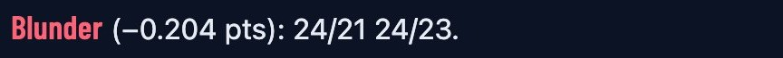

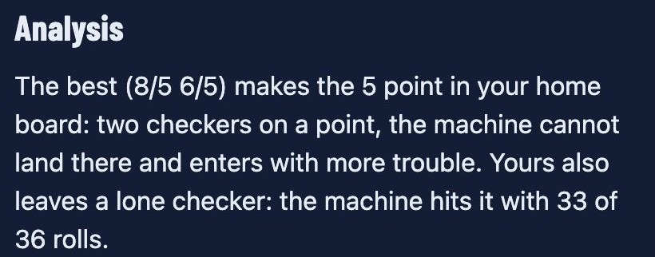

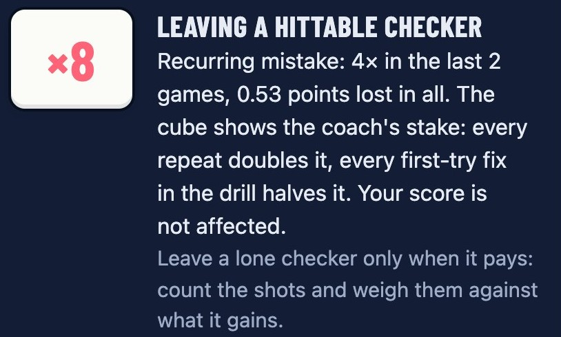

I measure its strength

Against an independent judge, on 6,548 real decisions.

**48.6%** of 2,000 games against Open Sage, an open-source engine: even, within the noise.

**World class** on GNU Backgammon’s rating scale for players.

## What I learned

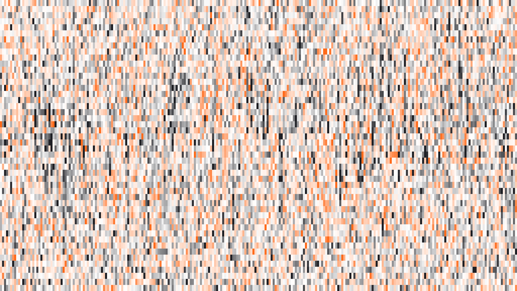

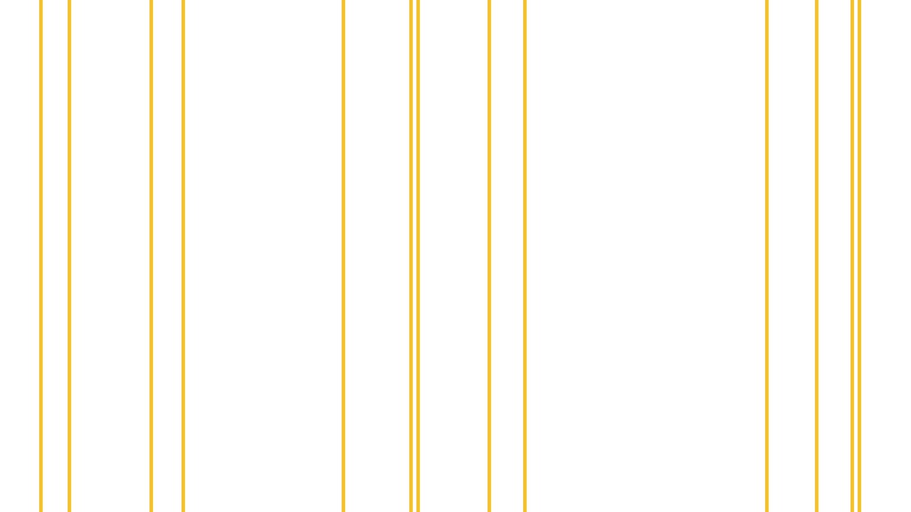

AI can modify a neural network.*

First layer of my backgammon network after 300,000 games.

**Gold: the units a language model rewrote, with its own concepts.**

**22 Nov, my research log:** it looked as if it could also read the network. But every fix it made to the units that training had shaped made the network worse. It understands what it wrote, not what the network learned.

* More in a few minutes.

## What’s next

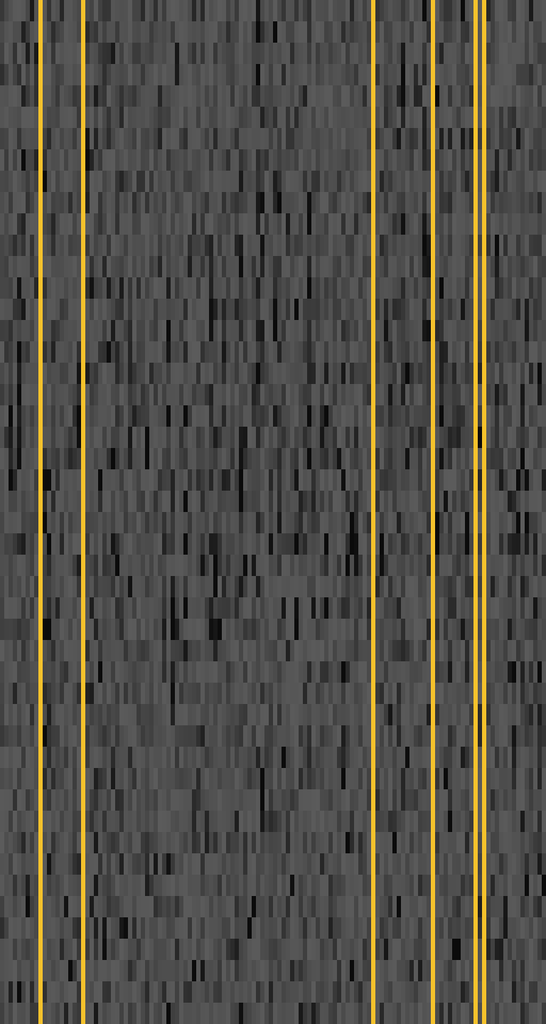

What’s next, for the product

1

Connect the chat.

So I can ask back.

2

Let it look at the activations.

With the new discovery, I’m curious what it sees in them.

3

Post it on r/backgammon.

Let real players try it.

## Blindspot Backgammon

Blindspot  
Backgammon

[arpadtamasi.github.io/backgammon](https://arpadtamasi.github.io/backgammon/)

**Árpád Tamási**Free · no account · works offline · English and Hungarian

[figure not shown]